# Pipeline DADA2

Ruben Chaboy

```r
knitr::opts_chunk$set(echo = TRUE)
```

# Tabla de contenidos

1. Carga de librerías
2. Parámetros
3. Preparación de datos
4. Filtrado de calidad y recorte de lecturas
5. Recuperación de identificadores
6. Inferencia de perfiles de error de secuenciación
7. Evaluación del modelo de error
8. Inferencia de ASVs y ensamblaje de lecturas paired-end
9. Procesamiento final

# Carga de librerías

```r
library(dada2)
```

# Parámetros

Aquí se definen los parámetros que se utilizarán más adelante:

- truncLen: el sitio de corte.
- maxmismatches: el máximo de desajustes entre las lecturas R1 y R2 durante el proceso de merging.
- removeBimeraDenovo_method: el método para eliminar quimeras.
- allowoneoff: wste parámetro permite que las secuencias que tengan un solo desajuste (es decir, un one-off error) sean aceptadas como secuencias válidas y no eliminadas. Esto es útil en caso de que las lecturas contengan errores de secuenciación.

```r
truncLen <- c(268, 218)
maxmismatches <- 1
removeBimeraDenovo_method <- "consensus"
allowoneoff <- TRUE
```

# Preparación de datos

En este chunk se indica el directorio de entrada donde están las lecturas forward (R1) y reverse (R2) y se crean las rutas de salida para las lecturas filtradas. Por último, se ordenan los archivos para continuar con el procesamiento.

```r
# Cambiar directorio según proceda

pathF <- "C:/Users/rubenuam/OneDrive/Tesis/Procesamiento/Prueba inicial dada2/data/R1/"
pathR <- "C:/Users/rubenuam/OneDrive/Tesis/Procesamiento/Prueba inicial dada2/data/R2/"

filtpathF <- file.path(pathF, "filtered")
filtpathR <- file.path(pathR, "filtered")

fastqFs <- sort(list.files(pathF, pattern="fastq"))
fastqRs <- sort(list.files(pathR, pattern="fastq"))
fastqRs #Comprobación
```

```
## [1] "Temp_A_1_1_S6_L001_R2_001.fastq"  "Temp_A_1_2_S13_L001_R2_001.fastq"
## [3] "Temp_A_1_3_S20_L001_R2_001.fastq"
```

# Filtrado de calidad y recorte de lecturas

Aquí se filtran las lecturas utilizando los parámetros por defecto de DADA2. Se recortan las lecturas a la longitud deseada y se eliminan las secuencias Phix.

```r
if(length(fastqFs) != length(fastqRs)) stop("La longitud de los archivos foward y reverse no coincide.")
trimmed <- filterAndTrim(fwd=file.path(pathF, fastqFs), filt=file.path(filtpathF, fastqFs),
              rev=file.path(pathR, fastqRs), filt.rev=file.path(filtpathR, fastqRs),
              truncLen=c(268,218), rm.phix=TRUE,
              compress=TRUE, verbose=TRUE, multithread=TRUE)
```

```
## Multithreading has been DISABLED, as forking is not supported on .Platform$OS.type 'windows'
```

```
## Overwriting file:C:\Users\rubenuam\OneDrive\Tesis\Procesamiento\Prueba inicial dada2\data\R1\filtered\Temp_A_1_1_S6_L001_R1_001.fastq
```

```
## Overwriting file:C:\Users\rubenuam\OneDrive\Tesis\Procesamiento\Prueba inicial dada2\data\R2\filtered\Temp_A_1_1_S6_L001_R2_001.fastq
```

```
## Read in 50425 paired-sequences, output 42742 (84.8%) filtered paired-sequences.
```

```
## Overwriting file:C:\Users\rubenuam\OneDrive\Tesis\Procesamiento\Prueba inicial dada2\data\R1\filtered\Temp_A_1_2_S13_L001_R1_001.fastq
```

```
## Overwriting file:C:\Users\rubenuam\OneDrive\Tesis\Procesamiento\Prueba inicial dada2\data\R2\filtered\Temp_A_1_2_S13_L001_R2_001.fastq
```

```
## Read in 34895 paired-sequences, output 29553 (84.7%) filtered paired-sequences.
```

```
## Overwriting file:C:\Users\rubenuam\OneDrive\Tesis\Procesamiento\Prueba inicial dada2\data\R1\filtered\Temp_A_1_3_S20_L001_R1_001.fastq
```

```
## Overwriting file:C:\Users\rubenuam\OneDrive\Tesis\Procesamiento\Prueba inicial dada2\data\R2\filtered\Temp_A_1_3_S20_L001_R2_001.fastq
```

```
## Read in 36305 paired-sequences, output 30712 (84.6%) filtered paired-sequences.
```

# Recuperación de identificadores

En este chunk se recuperan los identificadores originales de las muestras.

```r
filtFs <- list.files(filtpathF, pattern="fastq", full.names = TRUE)
filtRs <- list.files(filtpathR, pattern="fastq", full.names = TRUE)
sample.names <- sapply(strsplit(basename(filtFs), "_L001"), `[`, 1) # Asume que filename = samplename_XXX.fastq
sample.namesR <- sapply(strsplit(basename(filtRs), "_L001"), `[`, 1) # Asume que filename = samplename_XXX.fastq
if(!identical(sample.names, sample.namesR)) stop("La longitud de los archivos foward y reverse no coincide")
names(filtFs) <- sample.names
names(filtRs) <- sample.names
set.seed(100)
names(filtFs) #Comprobación
```

```
## [1] "Temp_A_1_1_S6"  "Temp_A_1_2_S13" "Temp_A_1_3_S20"
```

# Inferencia de perfiles de error de secuenciación

En este paso se estiman los perfiles de error de las lecturas forward y reverse, necesarios para la inferencia de variantes de secuencia en DADA2.

```r
errF <- learnErrors(filtFs, nbases=1e8, multithread=TRUE)
```

```
## 27605876 total bases in 103007 reads from 3 samples will be used for learning the error rates.
```

```r
errR <- learnErrors(filtRs, nbases=1e8, multithread=TRUE)
```

```
## 22455526 total bases in 103007 reads from 3 samples will be used for learning the error rates.
```

# Evaluación del modelo de error

Aquí se verifica visualmente que el modelo de errores aprendido por DADA2 es adecuado.

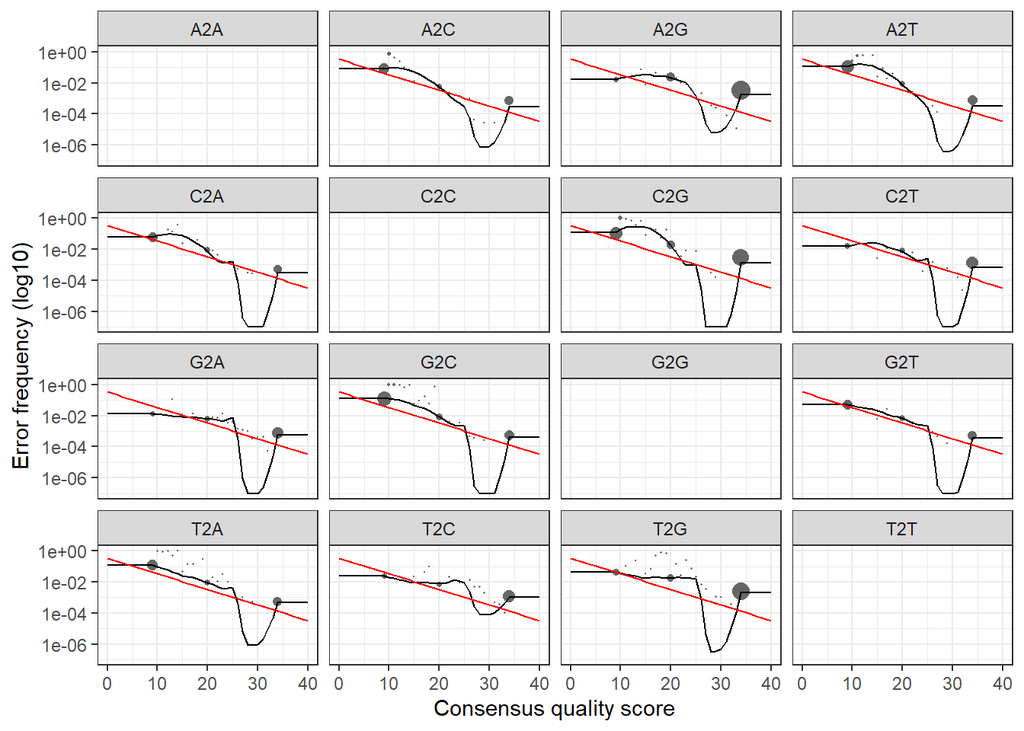

```r
plotErrors(errF, nominalQ=TRUE)
```

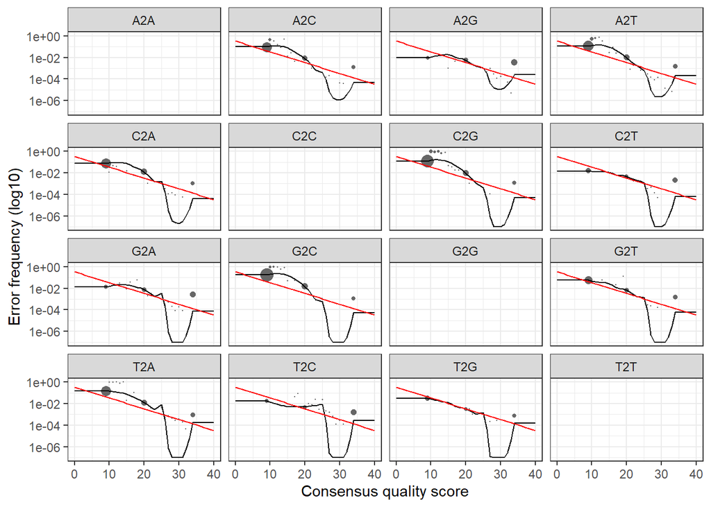

```r
plotErrors(errR, nominalQ=TRUE)
```

# Inferencia de ASVs y ensamblaje de lecturas paired-end

En este paso se realiza la inferencia de ASVs y la unión de las lecturas paired-end, generando secuencias completas a partir de las lecturas forward y reverse.

```r
mergers <- vector("list", length(sample.names))
names(mergers) <- sample.names
for(sam in sample.names) {
  cat("Processing:", sam, "\n")
    derepF <- derepFastq(filtFs[[sam]])
    ddF <- dada(derepF, err=errF, multithread=TRUE)
    derepR <- derepFastq(filtRs[[sam]])
    ddR <- dada(derepR, err=errR, multithread=TRUE)
    merger <- mergePairs(ddF, derepF, ddR, derepR,maxMismatch = maxmismatches, minOverlap = 12)
    mergers[[sam]] <- merger
}
```

```
## Processing: Temp_A_1_1_S6
## Sample 1 - 42742 reads in 4764 unique sequences.
## Sample 1 - 42742 reads in 9234 unique sequences.
```

```
## Duplicate sequences in merged output.
```

```
## Processing: Temp_A_1_2_S13
## Sample 1 - 29553 reads in 4455 unique sequences.
## Sample 1 - 29553 reads in 8273 unique sequences.
```

```
## Duplicate sequences in merged output.
```

```
## Processing: Temp_A_1_3_S20
## Sample 1 - 30712 reads in 6090 unique sequences.
## Sample 1 - 30712 reads in 10218 unique sequences.
```

```
## Duplicate sequences in merged output.
```

```r
rm(derepF); rm(derepR)

save.image("dada2multithreads_intermediate.RData")
```

# Procesamiento final

En este apartado se realiza la construcción de la tabla de secuencias, la eliminación de quimeras y la asignación taxonómica.

```r
# 1) Construcción de la tabla de secuencias

seqtab <- makeSequenceTable(mergers)
```

```
## Duplicate sequences detected and merged.
## Duplicate sequences detected and merged.
## Duplicate sequences detected and merged.
```

```r
View (seqtab)
seqtabtraspuesta <-t(seqtab)
View (seqtabtraspuesta)

# 2) Eliminación de quimeras

seqtab_nochim <- removeBimeraDenovo(seqtab, method=removeBimeraDenovo_method, multithread=TRUE,allowOneOff = allowoneoff)

# 3) Asignación taxonómica

tax <- assignTaxonomy(seqtab_nochim, "C:/Users/rubenuam/OneDrive/Tesis/Procesamiento/Prueba inicial dada2/silva_nr_v123_train_set.fa.gz", multithread=TRUE)

#4) Guardado (Cambiar directorio según proceda )

saveRDS(seqtab, "C:/Users/rubenuam/OneDrive/Tesis/Procesamiento/Prueba inicial dada2/seqtab_final.rds")

saveRDS(tax, "C:/Users/rubenuam/OneDrive/Tesis/Procesamiento/Prueba inicial dada2/tax_final.rds")

getN <- function(x) sum(getUniques(x))
track <- cbind(trimmed,
               sapply(mergers, getN),
               rowSums(seqtab_nochim))
```

```
## Duplicate sequences detected and merged.
## Duplicate sequences detected and merged.
## Duplicate sequences detected and merged.
```

```r
colnames(track) <- c('input', 'filtered', 'dada+merged', 'nochim')

save.image("dada2multithreads.RData")
```